# employee_data_vizualization

```
51.0
76.0
25.0
13.5
113.5
3.0
7.0
4.0
13.0 -3.0
```

```
(3487, 12)
```

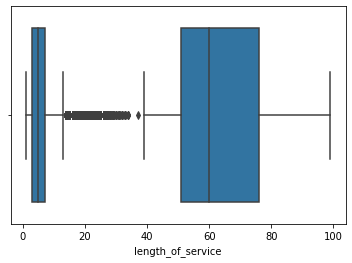

```python
import pandas as pd# we import pandas to handle the file and its save our lots of time, it handle large data set efficeintly.
import numpy as np #for creating arrays
import seaborn as sns #for data visualzation
import matplotlib.pyplot as plt # for data visualization

df1 = pd.read_csv(r'C:\Users\PC-chetan\Desktop\train.csv') # trian data

df2 = pd.read_csv(r'C:\Users\PC-chetan\Desktop\test.csv') # test data

df1.education.fillna("Bachelor's", inplace=True)

df2.education.fillna("Bachelor's", inplace=True)

df1.previous_year_rating.fillna('3.0',inplace=True)

df2.previous_year_rating.fillna('3.0',inplace=True)

from sklearn.preprocessing import LabelEncoder
le = LabelEncoder()

df1.drop(columns=['employee_id','region','recruitment_channel'], inplace=True)

df2.drop(columns=['employee_id','region','recruitment_channel'], inplace=True)

#lets encode the education in their degree of importance
df1['education'] = df1['education'].replace(("Master's & above", "Bachelor's", "Below Secondary"),
                                                (3, 2, 1))
df2['education'] = df2['education'].replace(("Master's & above", "Bachelor's", "Below Secondary"), (3, 2, 1))

df1.gender = le.fit_transform(df1.gender)

df1.department = le.fit_transform(df1.department)

df2.department = le.transform(df2.department)


df2['gender'] = df2['gender'].replace(("m", "f"),(1,0))





df1.shape

df1.select_dtypes('number').head()

df2.select_dtypes('number').head()

sns.boxplot(data=df1,x=df1['avg_training_score'])

df1.shape

Q1=df1['avg_training_score'].quantile(0.25)
Q3=df1['avg_training_score'].quantile(0.75)
IQR=Q3-Q1
print(Q1)
print(Q3)
print(IQR)
min_1 = Q1-(1.5)*IQR
max_1 = Q3+(1.5)*IQR
print(min_1)
print( max_1)


df1['avg_training_score'].unique()

df1 = df1[df1['avg_training_score']< max_1]

df1.shape


sns.boxplot(data=df1,x=df1['length_of_service'])

Q2=df1['length_of_service'].quantile(0.25)
Q4=df1['length_of_service'].quantile(0.75)
IQRt=Q4-Q2
print(Q2)
print(Q4)
print(IQRt)
min_2 = Q2-1.5*IQRt
max_2 = Q4+1.5*IQRt
print(max_2,min_2)

df1['length_of_service'].unique()
df1 = df1[df1['length_of_service'] > 13]


# feature engineering
#it is the most important part of the data preprocessing

df1.shape

df1['sum_metric'] = df1['awards_won?']+ df1['previous_year_rating']


# creating a total score column
df1['total_score'] = df1['avg_training_score'] * df1['no_of_trainings']


pd.set_option('display.max_rows', 5000) # for getting the max veiw of raws
pd.set_option('display.max_column', 5000) # for getting the max veiw of columns

df1[(df1['previous_year_rating'] == 1.0) &
      (df1['awards_won?'] == 0) & (df1['avg_training_score'] < 60) & (df1['is_promoted'] == 1)]

df1 = df1.drop(df1[(df1['previous_year_rating'] == 1.0) &
      (df1['awards_won?'] == 0) & (df1['avg_training_score'] < 60) & (df1['is_promoted'] == 1)].index)

df1.shape
```

## visualizations

- using
- univariate
- bivariate and
- multivariate analysisvizualisation

## 1. univariate:

- Univariate analysis is the simplest form of statistical analysis.
- The key fact is that only one variable is involved in Univariate Analysis.
- Univariate analysis can yield misleading results in cases in where multivariate analysis is more appropriate.
- This is an Essential step to understand the variables present in the dataset step by step.
- We can use Distribution plots to check the distribution of the Numerical Columns.
- We can check distribution of Categorical Columns using Pie charts, Count plots etc

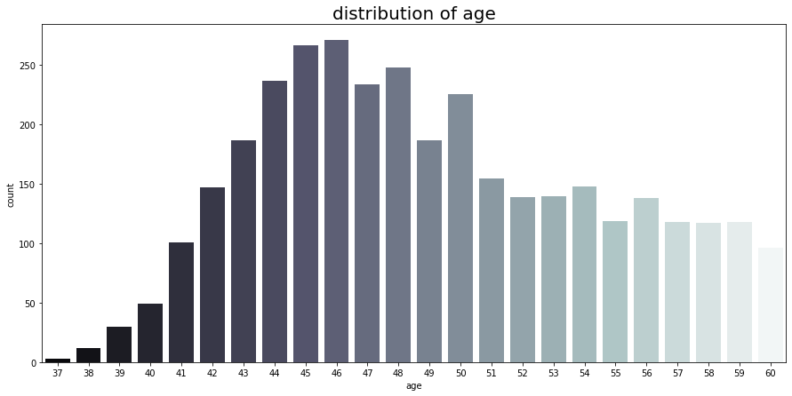

```python
plt.figure(figsize=(15,7))
sns.countplot(x='age', data = df1, palette= 'bone')
plt.title('distribution of age', fontsize = 20)
plt.show()
```

```python
df1.age.unique()
```

```
array([39, 59, 50, 60, 42, 43, 54, 45, 44, 46, 57, 58, 49, 55, 51, 52, 47,
       48, 53, 40, 56, 41, 38, 37], dtype=int64)
```

```python
# min age category = 37
# max age group = 46
```

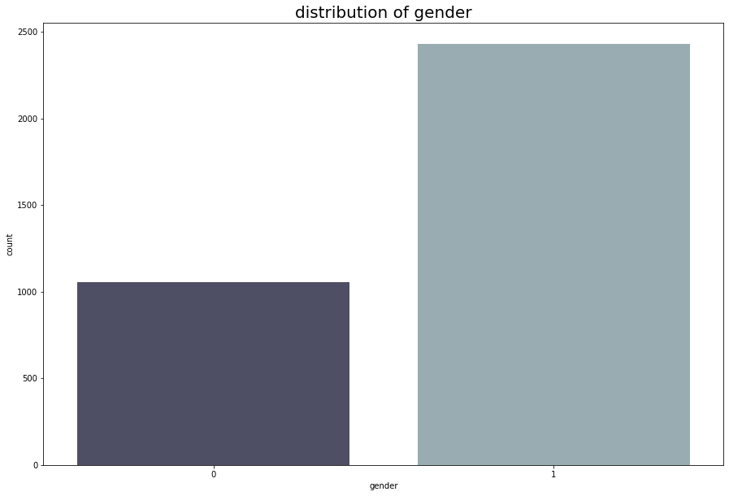

```python
plt.figure(figsize=(15,10))
sns.countplot(x='gender', data = df1, palette= 'bone')
plt.title('distribution of gender', fontsize = 20)
plt.show()
```

```python
df1.gender.value_counts()
```

```
1    2431
0    1056
Name: gender, dtype: int64
```

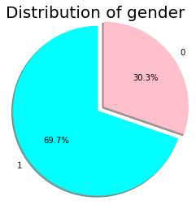

```python
q = df1['gender'].value_counts().index
w = df1['gender'].value_counts()
c=['cyan','pink']
e = [0, 0.1]
plt.pie(w,labels= q, colors = c, explode = e ,shadow = True, autopct='%1.1f%%',startangle = 90,  radius = 1.2)
plt.title('Distribution of gender ', fontsize = 20)
```

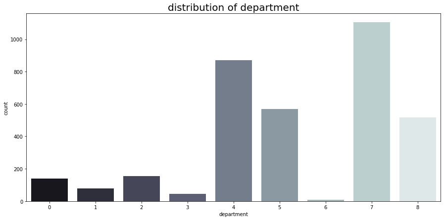

```python
plt.figure(figsize=(15,7))
sns.countplot(x='department', data = df1, palette= 'bone')
plt.title('distribution of department', fontsize = 20)
plt.show()
```

```python
# max number of employee in sales and marketing
# min number of employee in R&D department
```

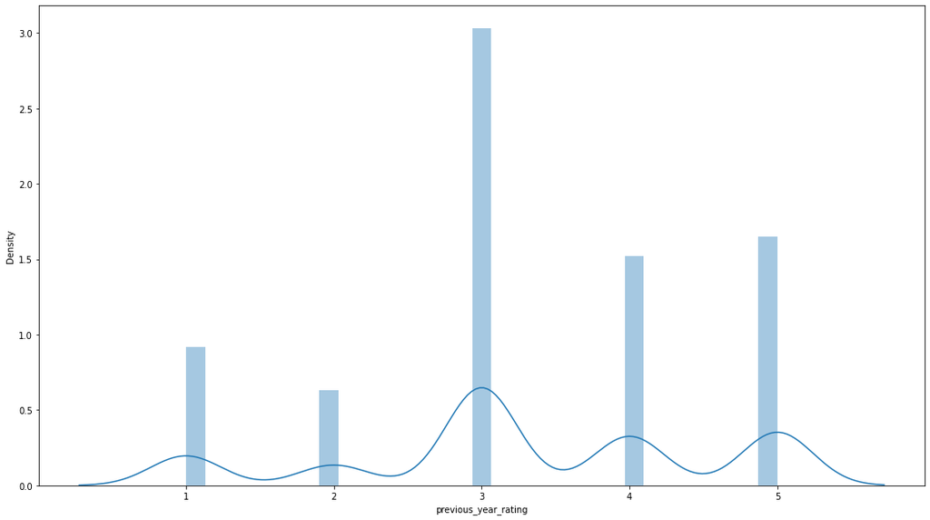

```python
x = df1['previous_year_rating']
plt.figure(figsize=(18,10))
sns.distplot(x)
plt.show()
```

```python
# most of the employee have 3 rating last year
```